# DESEQ2 - Initial

Iteration of DESEQ2 over: Top_level_filter (e.g. Tissue Region) level, then treatment comparison

Region level - e.g. Tissue region, indicates all DE data from same tissue and experiment. These are analysed independently from every other region.

Within a region, the treatments are compared.

However, for downstream plotting, the normalised data from all regions is calculated. Particularly important for co-expression related analysis.

To normalise gene expression across all tissues, the ’DESEQ2 - all tissues - FULL - **’ needs to be used.

# 1. Import metadata

| rowname | Diet | Region | ID | Lab_ID | Pen | Kill.Day | Diet0 | Region_Diet | rowname0 | sample_names |
| --- | --- | --- | --- | --- | --- | --- | --- | --- | --- | --- |
| ARC_01_HCP-HP-RMEI | HCP-HP-RMEI | ARC | 94 | RAMAC | 23 | 3 | HCP.HP.RMEI | ARC_HCP.HP.RMEI | ARC.01.HCP-HP-RMEI | ARC_94__HCP-HP-RMEI |
| ARC_02_HCP-HP-UMEI | HCP-HP-UMEI | ARC | 77 | RAMAC | 40 | 4 | HCP.HP.UMEI | ARC_HCP.HP.UMEI | ARC.02.HCP-HP-UMEI | ARC_77__HCP-HP-UMEI |
| ARC_03_HCP-LP-UMEI | HCP-LP-UMEI | ARC | 87 | RAMAC | 18 | 2 | HCP.LP.UMEI | ARC_HCP.LP.UMEI | ARC.03.HCP-LP-UMEI | ARC_87__HCP-LP-UMEI |
| ARC_04_LCP-HP-UMEI | LCP-HP-UMEI | ARC | 31 | RAMAC | 26 | 3 | LCP.HP.UMEI | ARC_LCP.HP.UMEI | ARC.04.LCP-HP-UMEI | ARC_31__LCP-HP-UMEI |
| ARC_05_HCP-LP-UMEI | HCP-LP-UMEI | ARC | 11 | RAMAC | 10 | 1 | HCP.LP.UMEI | ARC_HCP.LP.UMEI | ARC.05.HCP-LP-UMEI | ARC_11__HCP-LP-UMEI |
| ARC_06_HCP-LP-UMEI | HCP-LP-UMEI | ARC | 81 | RAMAC | 30 | 3 | HCP.LP.UMEI | ARC_HCP.LP.UMEI | ARC.06.HCP-LP-UMEI | ARC_81__HCP-LP-UMEI |
| ARC_07_HCP-LP-UMEI | HCP-LP-UMEI | ARC | 18 | RAMAC | 1 | 1 | HCP.LP.UMEI | ARC_HCP.LP.UMEI | ARC.07.HCP-LP-UMEI | ARC_18__HCP-LP-UMEI |
| ARC_08_HCP-LP-UMEI | HCP-LP-UMEI | ARC | 15 | RAMAC | 11 | 2 | HCP.LP.UMEI | ARC_HCP.LP.UMEI | ARC.08.HCP-LP-UMEI | ARC_15__HCP-LP-UMEI |
| ARC_09_HCP-HP-UMEI | HCP-HP-UMEI | ARC | 65 | RAMAC | 29 | 3 | HCP.HP.UMEI | ARC_HCP.HP.UMEI | ARC.09.HCP-HP-UMEI | ARC_65__HCP-HP-UMEI |
| ARC_10_LCP-LP-UMEI | LCP-LP-UMEI | ARC | 60 | RAMAC | 14 | 2 | LCP.LP.UMEI | ARC_LCP.LP.UMEI | ARC.10.LCP-LP-UMEI | ARC_60__LCP-LP-UMEI |

[output cut: 229 more lines]

# 2. import all count tables and join

```r
cts_all <- data.table::fread(file= "./extdata/cts_renamed_all_Sheep.txt")

# 1. Run check function
cts_filtered <- check_count_matrix(count_data = cts_all,
                            colData = coldata,
                            column_with_col_names = sample_names
                            )
```

```
PASS: All columns in count_data have matching data in colData
PASS: Rownames not detected
PASS: First column name is 'gene_ensembl'

 Dimensions of raw counts dataset BEFORE sorting:
genes:  27054     samples:  239

 Number of samples in colData: 239

 Dimensions of raw counts dataset AFTER sorting:
genes:  27054     samples:  239
```

```r
# 2. filter colData, if suggested by above (will work if not suggested anyway)
coldata <- subset_colData(count_data = cts_all,
                            colData = coldata,
                            column_with_col_names = sample_names)
```

```
All entries in colData have matching count_data column. Run full check with check_counts_matrix() function.
```

```r
# 3. re-run check
cts_filtered <- check_count_matrix(count_data = cts_all,
                            colData = coldata,
                            column_with_col_names = sample_names
                            )
```

```
PASS: All columns in count_data have matching data in colData
PASS: Rownames not detected
PASS: First column name is 'gene_ensembl'

 Dimensions of raw counts dataset BEFORE sorting:
genes:  27054     samples:  239

 Number of samples in colData: 239

 Dimensions of raw counts dataset AFTER sorting:
genes:  27054     samples:  239
```

```r
rm(cts_all)
```

# 3. convert ensemble ID to gene ID

```r
test_annot <-
  annotate_gene_ensembl(cts_filtered,
                        organism = "oaries",
                        base_URL = "http://biit.cs.ut.ee/gprofiler_archive3/e100_eg47_p14")
```

```
g:Profiler Version URL:  http://biit.cs.ut.ee/gprofiler_archive3/e100_eg47_p14
Using organism: oaries
Important - this produces duplicate gene names from annotation - however gene_ensembl remain unique.
      This is why it's important to use gene_ensembl for all tasks and annotate output at end.
```

```
[1] "duplicate genes in annotation:  1799"
```

```r
#used without internet connection
# temp <- data.table::fread(file="./outputs/normalised_counts/ARC_VST_normalisedcounts_20211117_1638.txt")
# test_annot <- temp %>% dplyr::select(gene_ensembl, gene_name, description)
# test_annot <- cts_filtered %>%
#   dplyr::select(gene_ensembl) %>%
# dplyr::left_join(test_annot)
```

# Prepare data

TO DO: make a wrapper for this with specific checks of data / auto matrix

```r
test_data <-
make_summarized_experiment_object(counts_data = cts_filtered,
                                  gene_annotations = test_annot,
                                  colData = coldata)



#subset columns to be every n, to make testing quicker
#test_data <- test_data[,seq(0,ncol(cts_filtered)-1,2)]
```

# 4. Generate DE results

The function `auto_generate_DE_results()` is iterated over using `purrr::map()`. For details on variables, see `?auto_generate_DE_results`. For multiple iterations it can take a long time to run. E.g. 6 Regions x 5 treatments of 8 samples (total n = 240) = ~30mins

```
 ******************* Start of -  ARC *******************


renaming the first element in assays to 'counts'
Warning in DESeq2::DESeqDataSet(se_data0, design = DESeq2_formula_design) :
  some variables in design formula are characters, converting to factors
Beginning DESeq analysis...
-- replacing outliers and refitting for 23 genes
-- DESeq argument 'minReplicatesForReplace' = 6
-- original counts are preserved in counts(dds)
Completed DESeq analysis.
Plotting cooks distance...
Cooks distance plot complete.
Generating pairwise DESeq2 results...
```

```
[1] "Contrast levels: ARC_HCP.HP.RMEI, ARC_HCP.HP.UMEI, ARC_HCP.LP.UMEI, ARC_LCP.HP.UMEI, ARC_LCP.LP.UMEI"
```

```
 log2 fold change (MLE): Region_Diet ARC_HCP.HP.RMEI vs ARC_HCP.HP.UMEI
```

```
out of 20363 with nonzero total read count
adjusted p-value < 0.05
LFC > 0 (up)       : 20, 0.098%
LFC < 0 (down)     : 2, 0.0098%
outliers [1]       : 0, 0%
[1] see 'cooksCutoff' argument of ?results
see metadata(res)$ihwResult on hypothesis weighting
```

```
 log2 fold change (MLE): Region_Diet ARC_HCP.HP.RMEI vs ARC_HCP.LP.UMEI
```

```
out of 20363 with nonzero total read count
adjusted p-value < 0.05
LFC > 0 (up)       : 6, 0.029%
LFC < 0 (down)     : 14, 0.069%
outliers [1]       : 0, 0%
[1] see 'cooksCutoff' argument of ?results
see metadata(res)$ihwResult on hypothesis weighting
```

```
 log2 fold change (MLE): Region_Diet ARC_HCP.HP.RMEI vs ARC_LCP.HP.UMEI
```

```
out of 20363 with nonzero total read count
adjusted p-value < 0.05
LFC > 0 (up)       : 0, 0%
LFC < 0 (down)     : 0, 0%
outliers [1]       : 0, 0%
[1] see 'cooksCutoff' argument of ?results
see metadata(res)$ihwResult on hypothesis weighting
```

```
 log2 fold change (MLE): Region_Diet ARC_HCP.HP.RMEI vs ARC_LCP.LP.UMEI
```

```
out of 20363 with nonzero total read count
adjusted p-value < 0.05
LFC > 0 (up)       : 3, 0.015%
LFC < 0 (down)     : 3, 0.015%
outliers [1]       : 0, 0%
[1] see 'cooksCutoff' argument of ?results
see metadata(res)$ihwResult on hypothesis weighting
```

```
 log2 fold change (MLE): Region_Diet ARC_HCP.HP.UMEI vs ARC_HCP.LP.UMEI
```

```
out of 20363 with nonzero total read count
adjusted p-value < 0.05
LFC > 0 (up)       : 0, 0%
LFC < 0 (down)     : 0, 0%
outliers [1]       : 0, 0%
[1] see 'cooksCutoff' argument of ?results
see metadata(res)$ihwResult on hypothesis weighting
```

```
 log2 fold change (MLE): Region_Diet ARC_HCP.HP.UMEI vs ARC_LCP.HP.UMEI
```

```
out of 20363 with nonzero total read count
adjusted p-value < 0.05
LFC > 0 (up)       : 2, 0.0098%
LFC < 0 (down)     : 6, 0.029%
outliers [1]       : 0, 0%
[1] see 'cooksCutoff' argument of ?results
see metadata(res)$ihwResult on hypothesis weighting
```

```
 log2 fold change (MLE): Region_Diet ARC_HCP.HP.UMEI vs ARC_LCP.LP.UMEI
```

```
out of 20363 with nonzero total read count
adjusted p-value < 0.05
LFC > 0 (up)       : 17, 0.083%
LFC < 0 (down)     : 27, 0.13%
outliers [1]       : 0, 0%
[1] see 'cooksCutoff' argument of ?results
see metadata(res)$ihwResult on hypothesis weighting
```

```
 log2 fold change (MLE): Region_Diet ARC_HCP.LP.UMEI vs ARC_LCP.HP.UMEI
```

```
out of 20363 with nonzero total read count
adjusted p-value < 0.05
LFC > 0 (up)       : 1, 0.0049%
LFC < 0 (down)     : 4, 0.02%
outliers [1]       : 0, 0%
[1] see 'cooksCutoff' argument of ?results
see metadata(res)$ihwResult on hypothesis weighting
```

```
 log2 fold change (MLE): Region_Diet ARC_HCP.LP.UMEI vs ARC_LCP.LP.UMEI
```

```
out of 20363 with nonzero total read count
adjusted p-value < 0.05
LFC > 0 (up)       : 0, 0%
LFC < 0 (down)     : 2, 0.0098%
outliers [1]       : 0, 0%
[1] see 'cooksCutoff' argument of ?results
see metadata(res)$ihwResult on hypothesis weighting
```

```
 log2 fold change (MLE): Region_Diet ARC_LCP.HP.UMEI vs ARC_LCP.LP.UMEI
```

```
out of 20363 with nonzero total read count
adjusted p-value < 0.05
LFC > 0 (up)       : 1, 0.0049%
LFC < 0 (down)     : 0, 0%
outliers [1]       : 0, 0%
[1] see 'cooksCutoff' argument of ?results
see metadata(res)$ihwResult on hypothesis weighting
```

```
Results generated.
Plotting MA plots (default DESeq2 style for QC)...
```

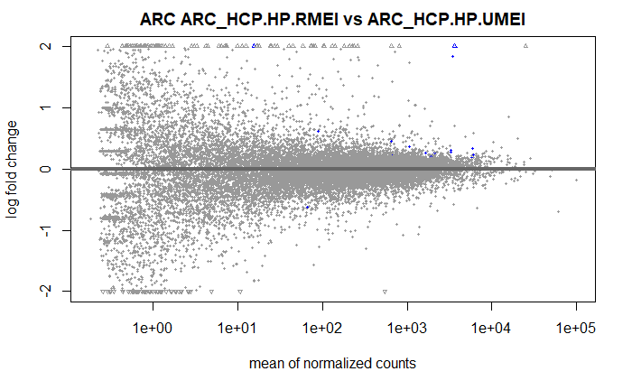

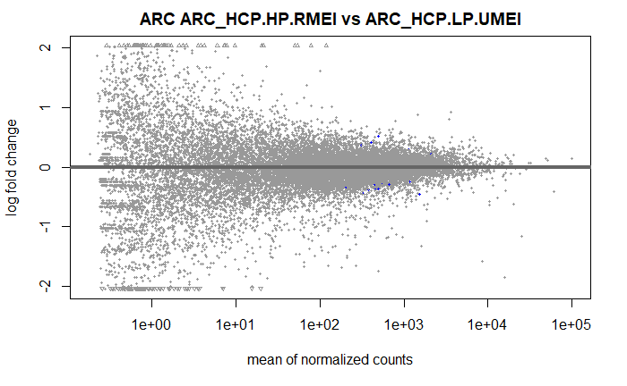

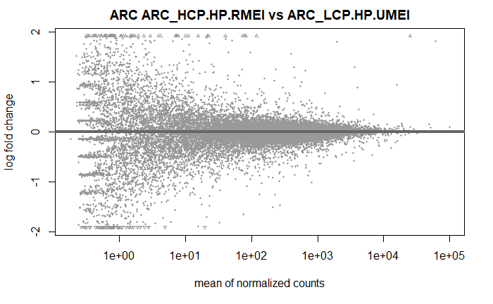

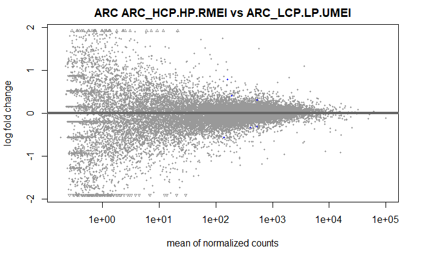

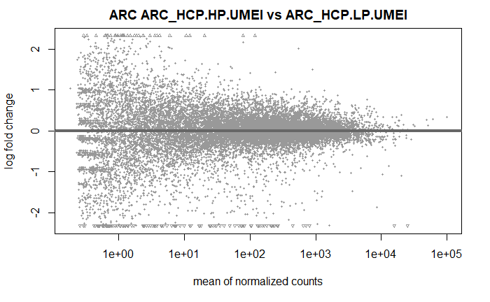

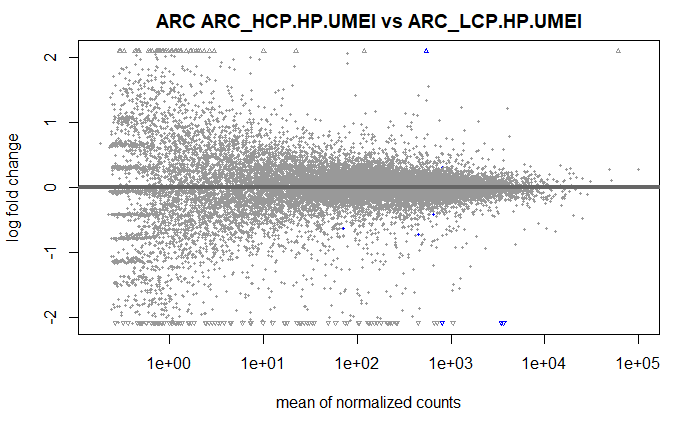

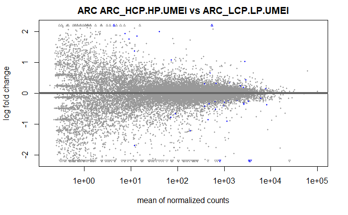

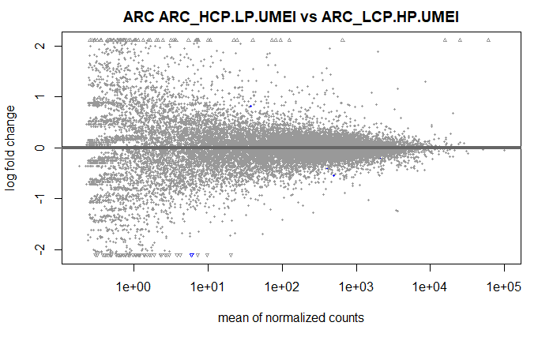

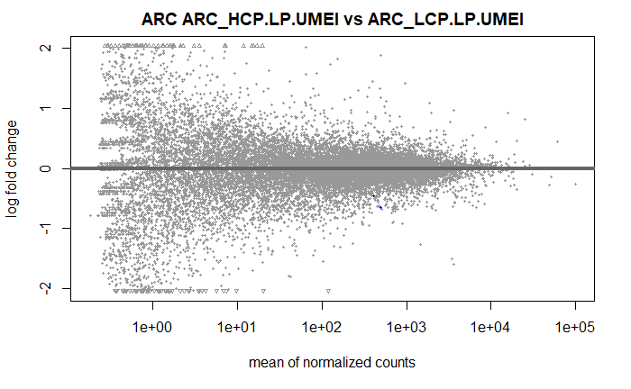

```
Finished MA plots.
Plotting p value histograms (for QC)...
```

[figure not shown]

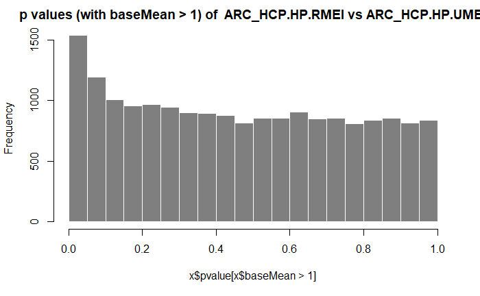

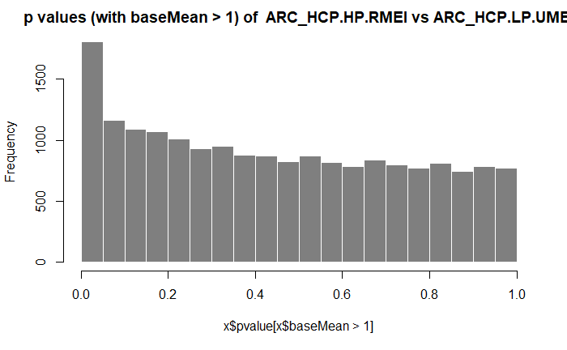

[34 more figures not shown]

```r
# regions <- coldata$Region %>% unique()

DE_out <-
  auto_generate_DE_results(se_data = test_data,
                           top_level_groups = c("ARC", "LIV"),
                           top_level_colname = Region,
                           sample_colname = sample_names,
                           samples_to_remove = NA,
                           DESeq2_formula_design = ~Region_Diet,
                           rowSums_filter = 10, #for dds filtering
                           results_contrast_factor = Region_Diet,
                           results_combinations = NA,
                           use_IHW_filtering = TRUE,
                           alpha = 0.05,
                           gene_annotations = test_annot,
                           export_tables = FALSE,
                           export_dir = "./outputs/",
                           whole_data_normalisation = FALSE)
```

# 5. Save Results

Saving to .rds compresses all of the data into one file that can be re-imported into RStudio, without having to re-run the very long commands above. It does not re-instate the whole image of the environment, just the output of auto_generate_DE_results() which has been unlisted so that every entry is named.

***The call to saveRDS() can take ~ 10 minutes and still produces a large file, particularly if many regions and samples are included. E.g. 40 samples x 6 regions = ~2.0 GB

```r
# Defaults to NOT RUN when running whole document.
#Save file as progress. Can be used as input instead of re-running all of the DESEQ functions.
saveRDS(DE_out, file = "./outputs/DE_out_file_testing.rds")

#to re-import to environment:
#DE_out2 <- readRDS(file = "./outputs/DE_out_file.rds")
```

# 6. Accessing Results

## 6.a. Accessor Functions

Firstly, the use of accessor functions that help to extract specific data are shown below. For plots, these also ‘view’ the plots, but is generally only useful for a code chunk that can show all plots, such as in this document (rather than if using in a .R file format). Note that the size of these plots is dictated by the `fig.width =` in the `{r }` at beginning of each code chunk.

These functions return a named list of 1 level. This means that individual elements of the list can be accessed by using $. For some plot types, viewing the individual plot using the $ will need to be done by copying to the Console. Do this if the plot does not appear below code chunk.

A description of more advanced access techniques is shown in next section.

### PIF Tables

All genes, sorted by PIF value. This function also allows searching to return only specified groups.

```r
PIF_tables_ALL <- GET_PIF_df(auto_DE_output = DE_out)

PIF_tables_ARC_and_LIV <- GET_PIF_df(auto_DE_output = DE_out,
                                  search_top_level = c("ARC", "LIV"))

rm(PIF_tables_ALL)
rm(PIF_tables_ARC_and_LIV)
```

### DE tables, sorted by PIF

Showing only significant genes, sorted on absolute PIF value. This function also allows searching to return only specified groups.

```r
DE_tables_ALL <- GET_DE_by_PIF_df(auto_DE_output = DE_out)

DE_tables_ARC_and_LIV <- GET_DE_by_PIF_df(auto_DE_output = DE_out,
                                          search_top_level = c("ARC", "LIV"))

rm(DE_tables_ALL)
rm(DE_tables_ARC_and_LIV)
```

#### Individual normalised counts tables

Note - these are largely not useful. See ?GET_normalised_counts Searches are not required, and either or both searches can be used.

```r
norm_ARC_log2 <- GET_normalised_data(auto_DE_output = DE_out,
                                     search_top_level = "ARC",
                                     vst_or_log2 = "Log2")
```

### Overall Plots

#### Boxplot of cooks distances

This has own function compared to others below. This is useful for both DE comparisons and when whole data normalisation has been run.

```r
pairwise_boxplots <- GET_boxplot_cooks_distance(auto_DE_output = DE_out)
```

#### PCA

```r
PCA_plots <- GET_overall_plots(auto_DE_output = DE_out,
                   type = "PCA")

#PCA_plots$ARC_DESeq2_Output
```

#### Heatmap

```r
heatmap_plots <- GET_overall_plots(auto_DE_output = DE_out,
                   type = "heatmap")
```

#### Sample distances

```r
sample_dist_plots <- GET_overall_plots(auto_DE_output = DE_out,
                   type = "sample_distances")
```

### Pairwise plots

#### Pvalue Histrograms

```r
pvalue_histograms <- GET_pairwise_plots(auto_DE_output = DE_out,
                                        type = "Pvalue",
                                        search_top_level = c("ARC", "LIV"))
```

#### MA Plots (for QC)

These are not the same MA plots which are generated with PIF, DE and annotations. This is rough plots from DESeq2.

```r
MA_plots <- GET_pairwise_plots(auto_DE_output = DE_out,
                               type = "MA",
                               search_top_level = c("ARC"))
```

### DESeqDataSet (dds_wald) objects

These are the DESeqDataSet objects (derived from the SummarizedExperiment object parsed to `auto_generate_DE_results`) after the call to DESeq2 (via `auto_generate_DE_results`).

```r
dds_objects <- GET_dds_wald_objects(auto_DE_output = DE_out,
                     search_top_level = "LIV")
#rm(dds_objects)
```

### Get results objects (class DESeqResults)

These are the results objects, containing all metadata, produced for each pairwise comparison. Most useful for accessing advanced information on how results were generated.

```r
results_objects <- GET_DESeq2_res_object(auto_DE_output = DE_out,
                                         search_top_level = c("ARC", "LIV"))

#rm(results_objects)
```

## 6.b. Manually accessing results

Overall, results can be accessed by using $ notation to navigate through the list. Search, unlisting and reduction techniques help to select data of interest.

The first level of the list can be accessed by using the $ sign. To see all available options use names().

```r
#DE_out$ARC_DESeq2_Output

DE_out %>% names()
```

Multiple $ can be used for recurring levels. Pressing the Tab button on keyboard shows options as well. Likewise, if a dataframe is the lowest level of the list that is accessed with a $, then it will also allow the column names to be accessed with $ as well.

```r
#Access a dataframe
DE_out$ARC_DESeq2_Output$DESeq2_annot_df$`ARC_HCP.HP.RMEI vs ARC_HCP.HP.UMEI`

#Access a column in a dataframe
DE_out$ARC_DESeq2_Output$DESeq2_annot_df$`ARC_HCP.HP.RMEI vs ARC_HCP.HP.UMEI`$gene_ensembl
```

Using a call to purrr::map with a string will iterate over each of the entries in the first level of the list and search within those lists to return a new list of only entries with matching names. This is basically what the functions use to access results.

```r
#Check what second level entries exist
DE_out$ARC_DESeq2_Output %>% names()
```

```r
#The string in call to map must be one of the options produced from above.
#This works because each Region's entry has the same underlying structure.
sample_accessed_object <-  DE_out %>%
  purrr::map("dds_wald_object")

sample_accessed_object %>%  str(max.level = 2)
```

```r
DE_out %>%
  purrr::map("DESeq2_res_object") %>%
  unlist(recursive = FALSE) %>%
  str(max.level = 2, list.len = 10) #shows the structure of the top 2 levels of the first 10 of 60 entries for easier reading
```

# 7. Filter and re-run

After viewing the results, particularly the cooks distances and the overall plots, a decision can be made to exclude outlier samples. For example, one might choose to remove the samples named: "ARC_88__LCP-LP-UMEI" and "LIV_77__HCP-HP-UMEI" This can be specified with an additional call to `auto_generate_DE_results` The same GET_* functions can then be used to access results from DE_out_2.

```r
#call DE again, without these samples
DE_out_2 <-
  auto_generate_DE_results(se_data = test_data$sample_names,
                           top_level_groups = c("ARC", "LIV"),
                           top_level_colname = Region,
                           sample_colname = sample_names,
                           samples_to_remove = c("ARC_88__LCP-LP-UMEI",
                                                 "LIV_77__HCP-HP-UMEI"),
                           DESeq2_formula_design = ~Region_Diet,
                           rowSums_filter = 10, #for dds filtering
                           results_contrast_factor = Region_Diet,
                           results_combinations = NA,
                           use_IHW_filtering = TRUE,
                           alpha = 0.05,
                           gene_annotations = test_annot,
                           export_tables = FALSE,
                           export_dir = "./outputs/",
                           whole_data_normalisation = FALSE)
```

# 8. Generate whole dataset normalised counts

Remember to include any samples to remove, if required.

```
Whole data normalisation selected. No pairwise results will be generated.
renaming the first element in assays to 'counts'
Warning in DESeq2::DESeqDataSet(se_data0, design = DESeq2_formula_design) :
  some variables in design formula are characters, converting to factors
Beginning DESeq analysis...
1 rows did not converge in beta, labelled in mcols(object)$betaConv. Use larger maxit argument with nbinomWaldTest
-- replacing outliers and refitting for 6 genes
-- DESeq argument 'minReplicatesForReplace' = 6
-- original counts are preserved in counts(dds)
Completed DESeq analysis.
Plotting cooks distance...
Cooks distance plot complete.
Preparing data for output...
List output succesfully generated.


 ******************* END *******************
```

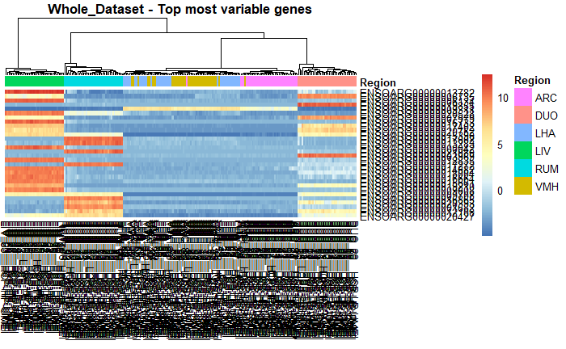

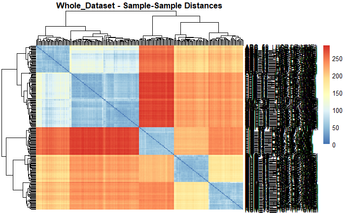

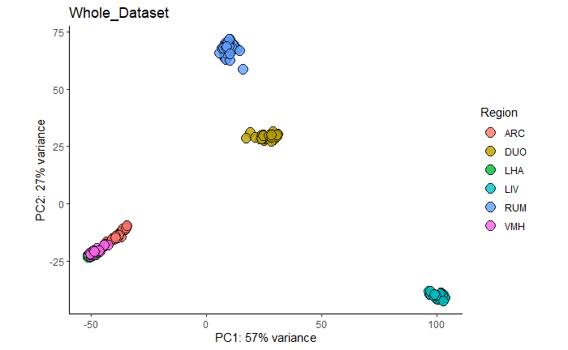

```r
full_norm <-
  auto_generate_DE_results(se_data = test_data,
                           top_level_colname = Region,
                           sample_colname = sample_names,
                           samples_to_remove = NA,
                           DESeq2_formula_design = ~Region_Diet,
                           gene_annotations = test_annot,
                           export_tables = FALSE,
                           export_dir = "./outputs/",
                           whole_data_normalisation = TRUE) #This is important!
```

# boxplot cooks distance

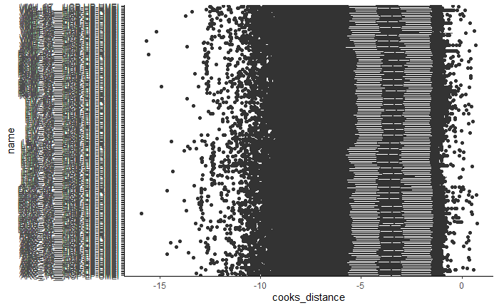

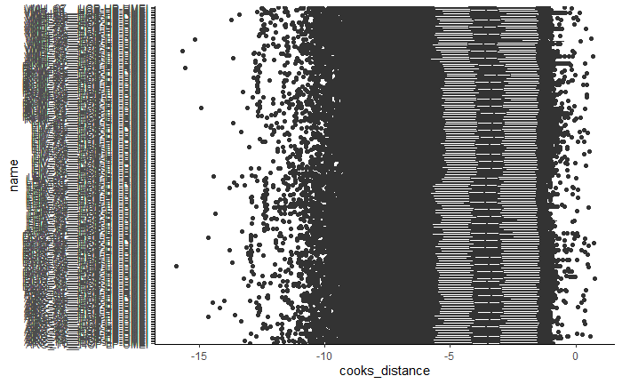

```r
#full_norm$Whole_data_normalisation_output$boxplot_cooks_distance
GET_boxplot_cooks_distance(full_norm)
```

#Working Code for renaming old cts tables